# R Notebook

# 1. Introduction

## 1.1. Abstract

Heart failure – sometimes known as congestive heart failure — occurs when the heart muscle doesn’t pump blood as well as it should. When this happens, blood often backs up, flows back and fluid can build up in the lungs, causing shortness of breath. Certain heart conditions, such as narrowed arteries in the heart (coronary artery disease) or high blood pressure, gradually leave the heart too weak or too stiff to fill and pump blood properly, and can lead to heart failure. Heart failure is a serious condition with high prevalence (about 2% in the adult population in developed countries, and more than 8% in patients older than 75 years). The cost for society is high, reaching up to 2% of total healthcare expenditure in developed countries. Hence the importance of being able to analyse and predict what factors are more likely to shorten the duration of life after heart failure is diagnosed

## 1.2. Dataset

This dataset contains the medical records of 299 patients who suffered heart failure. The data has been collected during their follow-up period, and each patient observation has 13 clinical features.

Thirteen (13) clinical features:

- age: age of the patient (in years)
- anaemia (0 for no, 1 for yes): decrease of red blood cells or hemoglobin (boolean)
- high blood pressure (0 for no, 1 for yes): if the patient has hypertension (boolean)
- creatinine phosphokinase (CPK): level of the CPK enzyme in the blood (mcg/L)
- diabetes (0 for no, 1 for yes): if the patient has diabetes (boolean)
- ejection fraction: percentage of blood leaving the heart at each contraction (percentage)
- platelets: platelets in the blood (kiloplatelets/mL)
- sex: woman or man (binary)
- serum creatinine: level of serum creatinine in the blood (mg/dL)
- serum sodium: level of serum sodium in the blood (mEq/L)
- smoking: if the patient smokes or not (boolean)
- time: follow-up period (days)
- [target] death event (0 for censored, 1 for death): if the patient deceased during the follow-up period (boolean)

Data source: https://archive.ics.uci.edu/ml/machine-learning-databases/00519/

## 1.3. Methodology

- General description of data
- Using Kaplan-Meir for the entire dataset and categorical variables
- Build Cox Proportional Hazard model.
- Variable selection on Cox model to determine the most relevant variables.
- Model diagnostics and tests.

# 2. Data exploration

```r
#load relevant packages


install.packages("survminer")
```

```
Error in install.packages : Updating loaded packages
```

```r
library(survminer)


library(survival)
library(ggplot2)
library(tidyverse)

if(!require(My.stepwise)){
    install.packages("My.stepwise")
    library(My.stepwise)
}

if(!require(corrr)){
    install.packages("corrr")
    library(corrr)
}

if(!require(gtools)){
    install.packages("gtools")
    library(gtools)
}

if(!require(caTools)){
    install.packages("caTools")
    library(caTools)
}

if(!require(MASS)){
    install.packages("MASS")
    library(MASS)
}


install.packages('pixiedust')
```

```
Error in install.packages : Updating loaded packages
```

```r
library(pixiedust)
```

```r
# load dataset

df <- read.csv("https://archive.ics.uci.edu/ml/machine-learning-databases/00519/heart_failure_clinical_records_dataset.csv")
df
```

| age | anaemia | creatinine_phosphokinase | diabetes | ejection_fraction | high_blood_pressure | platelets | serum_creatinine | serum_sodium | sex | smoking | time | DEATH_EVENT |
| --- | --- | --- | --- | --- | --- | --- | --- | --- | --- | --- | --- | --- |
| 75.000 | 0 | 582 | 0 | 20 | 1 | 265000 | 1.90 | 130 | 1 | 0 | 4 | 1 |
| 55.000 | 0 | 7861 | 0 | 38 | 0 | 263358 | 1.10 | 136 | 1 | 0 | 6 | 1 |
| 65.000 | 0 | 146 | 0 | 20 | 0 | 162000 | 1.30 | 129 | 1 | 1 | 7 | 1 |
| 50.000 | 1 | 111 | 0 | 20 | 0 | 210000 | 1.90 | 137 | 1 | 0 | 7 | 1 |
| 65.000 | 1 | 160 | 1 | 20 | 0 | 327000 | 2.70 | 116 | 0 | 0 | 8 | 1 |
| 90.000 | 1 | 47 | 0 | 40 | 1 | 204000 | 2.10 | 132 | 1 | 1 | 8 | 1 |
| 75.000 | 1 | 246 | 0 | 15 | 0 | 127000 | 1.20 | 137 | 1 | 0 | 10 | 1 |
| 60.000 | 1 | 315 | 1 | 60 | 0 | 454000 | 1.10 | 131 | 1 | 1 | 10 | 1 |
| 65.000 | 0 | 157 | 0 | 65 | 0 | 263358 | 1.50 | 138 | 0 | 0 | 10 | 1 |
| 80.000 | 1 | 123 | 0 | 35 | 1 | 388000 | 9.40 | 133 | 1 | 1 | 10 | 1 |

[output cut: 289 more lines]

```r
# Let's look at a summary of the explanatory variables
summary(df)
```

```
      age           anaemia       creatinine_phosphokinase    diabetes      ejection_fraction high_blood_pressure   platelets      serum_creatinine  serum_sodium        sex            smoking            time        DEATH_EVENT
 Min.   :40.00   Min.   :0.0000   Min.   :  23.0           Min.   :0.0000   Min.   :14.00     Min.   :0.0000      Min.   : 25100   Min.   :0.500    Min.   :113.0   Min.   :0.0000   Min.   :0.0000   Min.   :  4.0   Min.   :0.0000
 1st Qu.:51.00   1st Qu.:0.0000   1st Qu.: 116.5           1st Qu.:0.0000   1st Qu.:30.00     1st Qu.:0.0000      1st Qu.:212500   1st Qu.:0.900    1st Qu.:134.0   1st Qu.:0.0000   1st Qu.:0.0000   1st Qu.: 73.0   1st Qu.:0.0000
 Median :60.00   Median :0.0000   Median : 250.0           Median :0.0000   Median :38.00     Median :0.0000      Median :262000   Median :1.100    Median :137.0   Median :1.0000   Median :0.0000   Median :115.0   Median :0.0000
 Mean   :60.83   Mean   :0.4314   Mean   : 581.8           Mean   :0.4181   Mean   :38.08     Mean   :0.3512      Mean   :263358   Mean   :1.394    Mean   :136.6   Mean   :0.6488   Mean   :0.3211   Mean   :130.3   Mean   :0.3211
 3rd Qu.:70.00   3rd Qu.:1.0000   3rd Qu.: 582.0           3rd Qu.:1.0000   3rd Qu.:45.00     3rd Qu.:1.0000      3rd Qu.:303500   3rd Qu.:1.400    3rd Qu.:140.0   3rd Qu.:1.0000   3rd Qu.:1.0000   3rd Qu.:203.0   3rd Qu.:1.0000
 Max.   :95.00   Max.   :1.0000   Max.   :7861.0           Max.   :1.0000   Max.   :80.00     Max.   :1.0000      Max.   :850000   Max.   :9.400    Max.   :148.0   Max.   :1.0000   Max.   :1.0000   Max.   :285.0   Max.   :1.0000
```

```r
summary(df$age)
```

```
   Min. 1st Qu.  Median    Mean 3rd Qu.    Max.
  40.00   51.00   60.00   60.83   70.00   95.00
```

```r
# Quick view at the target variable distribution: target DEATH EVENT is a bollean
table(df$DEATH_EVENT)
```

```
  0   1
203  96
```

```r
### Check for Missing Values
colSums(is.na(df))
```

```
                     age                  anaemia creatinine_phosphokinase                 diabetes        ejection_fraction      high_blood_pressure                platelets         serum_creatinine             serum_sodium                      sex                  smoking                     time
                       0                        0                        0                        0                        0                        0                        0                        0                        0                        0                        0                        0
             DEATH_EVENT
                       0
```

## 3. Models

### 3.1. Kaplan Meir

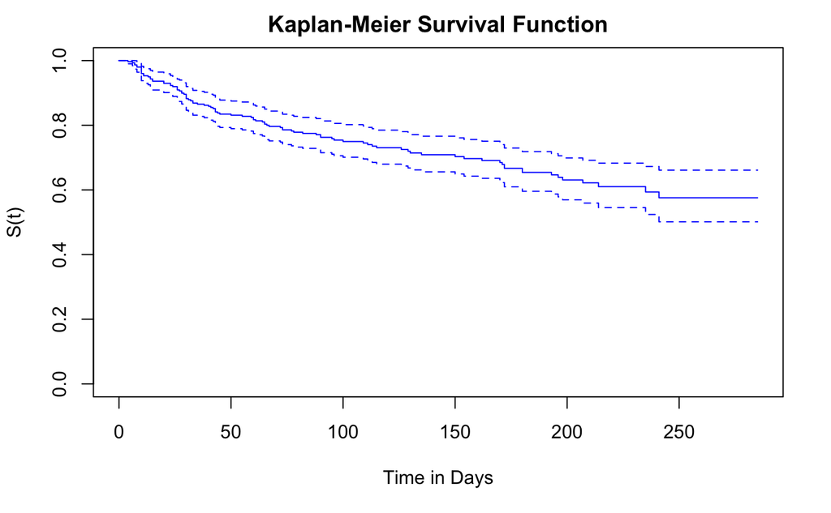

```r
df_time=as.vector(df$time)
df_death=as.vector(df$DEATH_EVENT)
df_fit = surv_fit(Surv(df_time,df_death)~1, data=df)
plot(df_fit, main = "Kaplan-Meier Survival Function", xlab = "Time in Days", ylab = "S(t)", col = "blue")
```

```r
quantile(df_fit,c(0.25))$q # survival time at 25th percentile
```

```
 25
100
```

```r
quantile(df_fit,c(0.5))$q  # survival time at 50th percentile
```

```
50
NA
```

```r
sfit <- summary(df_fit)
sfit$surv[sfit$time == 50]
```

```
[1] 0.8310352
```

The survival function never goes down 0.5, then no median survival rate. The probability of surviving past 50 days is 83.1%

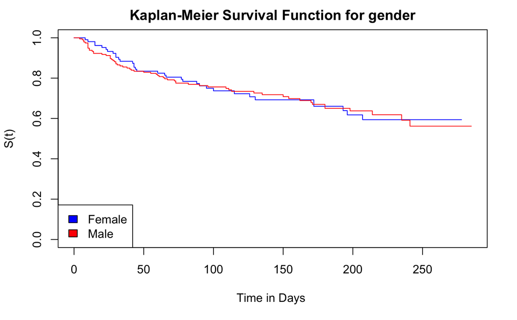

```r
#KM graphs adjusted for various categorical variables:


df_sex = as.factor(df$sex)
df_sex_fit = surv_fit(Surv(df_time,df_death)~sex, data=df)

plot(df_sex_fit,
     main = "Kaplan-Meier Survival Function for gender",
     xlab = "Time in Days ",
     ylab = "S(t)",
     col= c("blue","red"))
legend("bottomleft",legend = c("Female","Male"),fill=c("blue","red"))
```

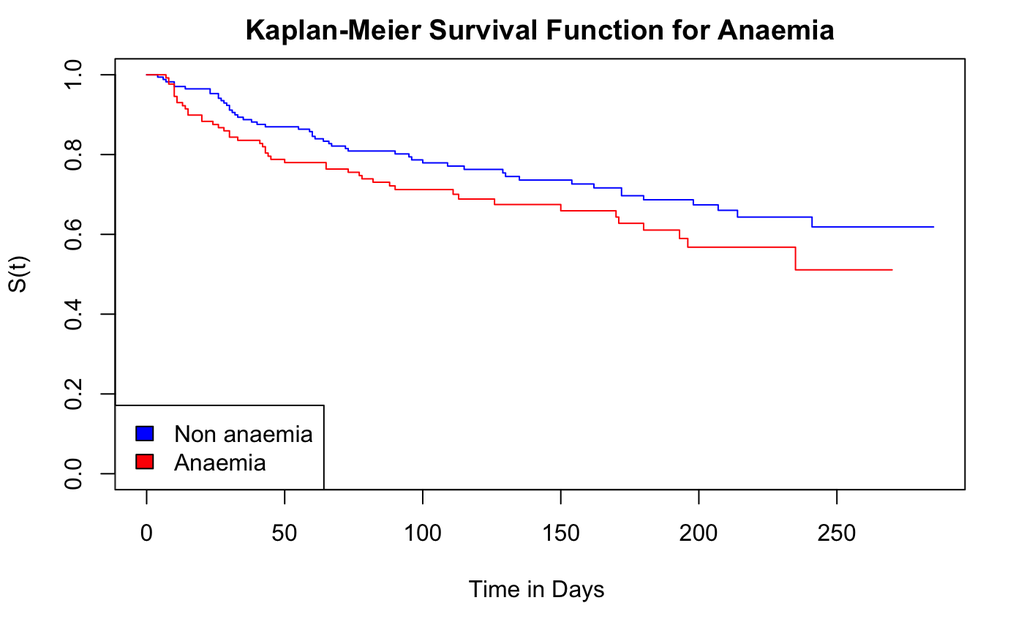

```r
df_anaemia = as.factor(df$anaemia)
df_anaemia_fit = surv_fit(Surv(df_time,df_death)~df_anaemia, data=df)
plot(df_anaemia_fit, main = "Kaplan-Meier Survival Function for Anaemia", xlab = "Time in Days ", ylab = "S(t)", col= c("blue","red"))
legend("bottomleft",legend = c("Non anaemia","Anaemia"),fill=c("blue","red"))
```

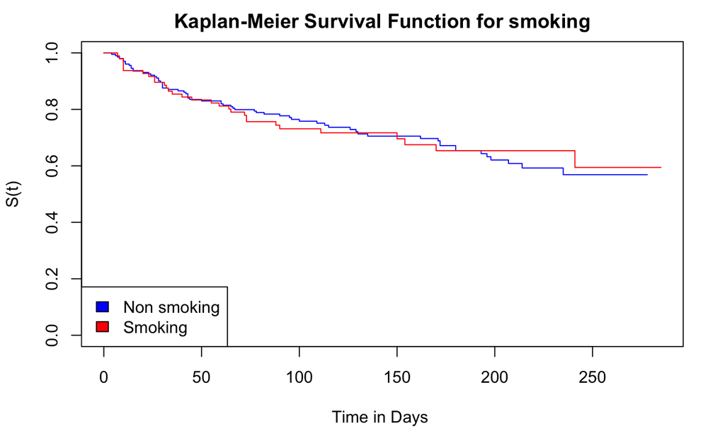

```r
df_smoking = as.factor(df$smoking)
df_smoking_fit = surv_fit(Surv(df_time,df_death)~df_smoking, data=df)
plot(df_smoking_fit, main = "Kaplan-Meier Survival Function for smoking", xlab = "Time in Days ", ylab = "S(t)", col= c("blue","red"))
legend("bottomleft",legend = c("Non smoking","Smoking"),fill=c("blue","red"))
```

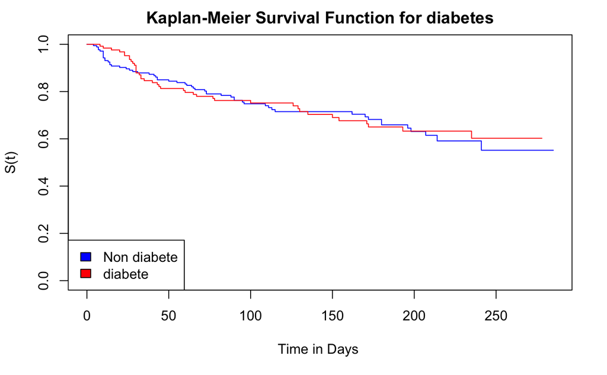

```r
df_diabetes = as.factor(df$diabetes)
df_diabetes_fit = surv_fit(Surv(df_time,df_death)~df_diabetes, data=df)
plot(df_diabetes_fit, main = "Kaplan-Meier Survival Function for diabetes", xlab = "Time in Days ", ylab = "S(t)", col= c("blue","red"))
legend("bottomleft",legend = c("Non diabete","diabete"),fill=c("blue","red"))
```

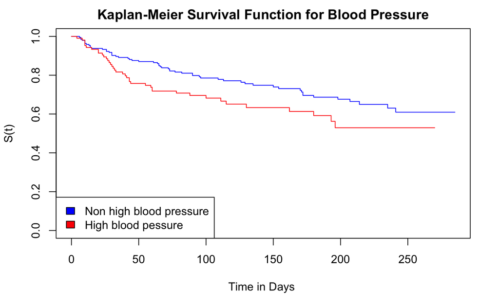

```r
df_blood = as.factor(df$high_blood_pressure)
df_blood_fit = surv_fit(Surv(df_time,df_death)~df_blood, data=df)
plot(df_blood_fit, main = "Kaplan-Meier Survival Function for Blood Pressure", xlab = "Time in Days ", ylab = "S(t)", col= c("blue","red"))
legend("bottomleft",legend = c("Non high blood pressure","High blood pessure"),fill=c("blue","red"))
```

```r
survdiff (Surv(df_time,df_death)~sex, data=df)
```

```
Call:
survdiff(formula = Surv(df_time, df_death) ~ sex, data = df)

        N Observed Expected (O-E)^2/E (O-E)^2/V
sex=0 105       34     34.3   0.00254   0.00397
sex=1 194       62     61.7   0.00141   0.00397

 Chisq= 0  on 1 degrees of freedom, p= 0.9
```

```r
survdiff (Surv(df_time,df_death)~df_anaemia, data=df)
```

```
Call:
survdiff(formula = Surv(df_time, df_death) ~ df_anaemia, data = df)

               N Observed Expected (O-E)^2/E (O-E)^2/V
df_anaemia=0 170       50     57.9      1.07      2.73
df_anaemia=1 129       46     38.1      1.63      2.73

 Chisq= 2.7  on 1 degrees of freedom, p= 0.1
```

```r
survdiff (Surv(df_time,df_death)~df_smoking, data=df)
```

```
Call:
survdiff(formula = Surv(df_time, df_death) ~ df_smoking, data = df)

               N Observed Expected (O-E)^2/E (O-E)^2/V
df_smoking=0 203       66     65.8   0.00064   0.00204
df_smoking=1  96       30     30.2   0.00139   0.00204

 Chisq= 0  on 1 degrees of freedom, p= 1
```

```r
survdiff (Surv(df_time,df_death)~df_diabetes, data=df)
```

```
Call:
survdiff(formula = Surv(df_time, df_death) ~ df_diabetes, data = df)

                N Observed Expected (O-E)^2/E (O-E)^2/V
df_diabetes=0 174       56       55    0.0172    0.0405
df_diabetes=1 125       40       41    0.0231    0.0405

 Chisq= 0  on 1 degrees of freedom, p= 0.8
```

```r
survdiff (Surv(df_time,df_death)~df_blood, data=df)
```

```
Call:
survdiff(formula = Surv(df_time, df_death) ~ df_blood, data = df)

             N Observed Expected (O-E)^2/E (O-E)^2/V
df_blood=0 194       57     66.4      1.34      4.41
df_blood=1 105       39     29.6      3.00      4.41

 Chisq= 4.4  on 1 degrees of freedom, p= 0.04
```

## 3.2. Cox proportional hazard model:

```r
# splitting data between train and test sets
data_split <- sample.split(df, SplitRatio = 0.80)
train <- subset(df, data_split == TRUE)
test <-subset(df, data_split == FALSE)
```

```r
train_time=as.vector(train$time)
train_death=as.vector(train$DEATH_EVENT)
train
```

|  | age | anaemia | creatinine_phosphokinase | diabetes | ejection_fraction | high_blood_pressure | platelets | serum_creatinine | serum_sodium | sex | smoking | time | DEATH_EVENT |
| --- | --- | --- | --- | --- | --- | --- | --- | --- | --- | --- | --- | --- | --- |
| 1 | 75.000 | 0 | 582 | 0 | 20 | 1 | 265000 | 1.90 | 130 | 1 | 0 | 4 | 1 |
| 2 | 55.000 | 0 | 7861 | 0 | 38 | 0 | 263358 | 1.10 | 136 | 1 | 0 | 6 | 1 |
| 4 | 50.000 | 1 | 111 | 0 | 20 | 0 | 210000 | 1.90 | 137 | 1 | 0 | 7 | 1 |
| 5 | 65.000 | 1 | 160 | 1 | 20 | 0 | 327000 | 2.70 | 116 | 0 | 0 | 8 | 1 |
| 6 | 90.000 | 1 | 47 | 0 | 40 | 1 | 204000 | 2.10 | 132 | 1 | 1 | 8 | 1 |
| 7 | 75.000 | 1 | 246 | 0 | 15 | 0 | 127000 | 1.20 | 137 | 1 | 0 | 10 | 1 |
| 10 | 80.000 | 1 | 123 | 0 | 35 | 1 | 388000 | 9.40 | 133 | 1 | 1 | 10 | 1 |
| 11 | 75.000 | 1 | 81 | 0 | 38 | 1 | 368000 | 4.00 | 131 | 1 | 1 | 10 | 1 |
| 12 | 62.000 | 0 | 231 | 0 | 25 | 1 | 253000 | 0.90 | 140 | 1 | 1 | 10 | 1 |
| 13 | 45.000 | 1 | 981 | 0 | 30 | 0 | 136000 | 1.10 | 137 | 1 | 0 | 11 | 1 |

[output cut: 220 more lines]

```r
test
```

|  | age | anaemia | creatinine_phosphokinase | diabetes | ejection_fraction | high_blood_pressure | platelets | serum_creatinine | serum_sodium | sex | smoking | time | DEATH_EVENT |
| --- | --- | --- | --- | --- | --- | --- | --- | --- | --- | --- | --- | --- | --- |
| 3 | 65 | 0 | 146 | 0 | 20 | 0 | 162000 | 1.30 | 129 | 1 | 1 | 7 | 1 |
| 8 | 60 | 1 | 315 | 1 | 60 | 0 | 454000 | 1.10 | 131 | 1 | 1 | 10 | 1 |
| 9 | 65 | 0 | 157 | 0 | 65 | 0 | 263358 | 1.50 | 138 | 0 | 0 | 10 | 1 |
| 16 | 82 | 1 | 379 | 0 | 50 | 0 | 47000 | 1.30 | 136 | 1 | 0 | 13 | 1 |
| 21 | 65 | 1 | 52 | 0 | 25 | 1 | 276000 | 1.30 | 137 | 0 | 0 | 16 | 0 |
| 22 | 65 | 1 | 128 | 1 | 30 | 1 | 297000 | 1.60 | 136 | 0 | 0 | 20 | 1 |
| 29 | 58 | 1 | 60 | 0 | 38 | 0 | 153000 | 5.80 | 134 | 1 | 0 | 26 | 1 |
| 34 | 50 | 1 | 159 | 1 | 30 | 0 | 302000 | 1.20 | 138 | 0 | 0 | 29 | 0 |
| 35 | 65 | 0 | 94 | 1 | 50 | 1 | 188000 | 1.00 | 140 | 1 | 0 | 29 | 1 |
| 42 | 50 | 0 | 124 | 1 | 30 | 1 | 153000 | 1.20 | 136 | 0 | 1 | 32 | 1 |

[output cut: 59 more lines]

```r
set.seed(1234)
i.training <- sample.int(nrow(df), size = ceiling(4*nrow(df)/5), replace = FALSE)
i.testing <- setdiff(seq_len(nrow(df)), i.training)
df_training <- df[i.training, ]
df_testing <- df[i.testing, ]

df_training
```

|  | age | anaemia | creatinine_phosphokinase | diabetes | ejection_fraction | high_blood_pressure | platelets | serum_creatinine | serum_sodium | sex | smoking | time | DEATH_EVENT |
| --- | --- | --- | --- | --- | --- | --- | --- | --- | --- | --- | --- | --- | --- |
| 284 | 65.000 | 0 | 1688 | 0 | 38 | 0 | 263358 | 1.10 | 138 | 1 | 1 | 250 | 0 |
| 101 | 65.000 | 1 | 305 | 0 | 25 | 0 | 298000 | 1.10 | 141 | 1 | 0 | 87 | 0 |
| 111 | 85.000 | 0 | 129 | 0 | 60 | 0 | 306000 | 1.20 | 132 | 1 | 1 | 90 | 1 |
| 133 | 46.000 | 0 | 719 | 0 | 40 | 1 | 263358 | 1.18 | 137 | 0 | 0 | 107 | 0 |
| 98 | 70.000 | 1 | 59 | 0 | 60 | 0 | 255000 | 1.10 | 136 | 0 | 0 | 85 | 0 |
| 103 | 80.000 | 0 | 898 | 0 | 25 | 0 | 149000 | 1.10 | 144 | 1 | 1 | 87 | 0 |
| 214 | 48.000 | 1 | 131 | 1 | 30 | 1 | 244000 | 1.60 | 130 | 0 | 0 | 193 | 1 |
| 90 | 57.000 | 1 | 115 | 0 | 25 | 1 | 181000 | 1.10 | 144 | 1 | 0 | 79 | 0 |
| 79 | 75.000 | 1 | 203 | 1 | 38 | 1 | 283000 | 0.60 | 131 | 1 | 1 | 74 | 0 |
| 270 | 40.000 | 0 | 582 | 1 | 35 | 0 | 222000 | 1.00 | 132 | 1 | 0 | 244 | 0 |

[output cut: 230 more lines]

```r
library(tidyverse)
```

```r
#Model with all variables:


cox_fit_all_training= coxph(Surv(time,DEATH_EVENT) ~ age + creatinine_phosphokinase + anaemia + diabetes + ejection_fraction + high_blood_pressure + platelets + serum_creatinine + serum_sodium + sex + smoking, df_training)


summary (cox_fit_all_training)
```

```
Call:
coxph(formula = Surv(time, DEATH_EVENT) ~ age + creatinine_phosphokinase +
    anaemia + diabetes + ejection_fraction + high_blood_pressure +
    platelets + serum_creatinine + serum_sodium + sex + smoking,
    data = df_training)

  n= 240, number of events= 79

                               coef  exp(coef)   se(coef)      z Pr(>|z|)
age                       4.145e-02  1.042e+00  1.055e-02  3.929 8.53e-05 ***
creatinine_phosphokinase  2.018e-04  1.000e+00  1.096e-04  1.842   0.0655 .
anaemia                   3.416e-01  1.407e+00  2.418e-01  1.413   0.1577
diabetes                  3.198e-01  1.377e+00  2.485e-01  1.287   0.1981
ejection_fraction        -5.013e-02  9.511e-01  1.181e-02 -4.243 2.21e-05 ***
high_blood_pressure       4.596e-01  1.583e+00  2.344e-01  1.961   0.0499 *
platelets                -1.035e-07  1.000e+00  1.393e-06 -0.074   0.9408
serum_creatinine          3.325e-01  1.394e+00  7.467e-02  4.453 8.47e-06 ***
serum_sodium             -6.065e-02  9.412e-01  2.913e-02 -2.082   0.0374 *
sex                      -1.027e-01  9.024e-01  2.874e-01 -0.357   0.7208
smoking                   2.474e-01  1.281e+00  2.787e-01  0.888   0.3747
---
Signif. codes:  0 ‘***’ 0.001 ‘**’ 0.01 ‘*’ 0.05 ‘.’ 0.1 ‘ ’ 1

                         exp(coef) exp(-coef) lower .95 upper .95
age                         1.0423     0.9594    1.0210    1.0641
creatinine_phosphokinase    1.0002     0.9998    1.0000    1.0004
anaemia                     1.4072     0.7106    0.8761    2.2603
diabetes                    1.3768     0.7263    0.8460    2.2405
ejection_fraction           0.9511     1.0514    0.9293    0.9734
high_blood_pressure         1.5835     0.6315    1.0001    2.5069
platelets                   1.0000     1.0000    1.0000    1.0000
serum_creatinine            1.3945     0.7171    1.2046    1.6142
serum_sodium                0.9412     1.0625    0.8889    0.9965
sex                         0.9024     1.1082    0.5138    1.5850
smoking                     1.2807     0.7808    0.7416    2.2117

Concordance= 0.745  (se = 0.03 )
Likelihood ratio test= 68.83  on 11 df,   p=2e-10
Wald test            = 74.33  on 11 df,   p=2e-11
Score (logrank) test = 76.25  on 11 df,   p=8e-12
```

It is clear that age, ejection_fraction, serum_creatinine are the most significant variables

```r
#Three-variable model:
cox3_fit_training = coxph(Surv(time,DEATH_EVENT) ~ age +ejection_fraction + serum_creatinine, data=df_training)
summary (cox3_fit_training)
```

```
Call:
coxph(formula = Surv(time, DEATH_EVENT) ~ age + ejection_fraction +
    serum_creatinine, data = df_training)

  n= 240, number of events= 79

                      coef exp(coef) se(coef)      z Pr(>|z|)
age                0.03677   1.03745  0.01012  3.633  0.00028 ***
ejection_fraction -0.05312   0.94827  0.01130 -4.702 2.58e-06 ***
serum_creatinine   0.36802   1.44487  0.07160  5.140 2.75e-07 ***
---
Signif. codes:  0 ‘***’ 0.001 ‘**’ 0.01 ‘*’ 0.05 ‘.’ 0.1 ‘ ’ 1

                  exp(coef) exp(-coef) lower .95 upper .95
age                  1.0375     0.9639    1.0171    1.0582
ejection_fraction    0.9483     1.0546    0.9275    0.9695
serum_creatinine     1.4449     0.6921    1.2557    1.6626

Concordance= 0.723  (se = 0.033 )
Likelihood ratio test= 55.24  on 3 df,   p=6e-12
Wald test            = 60.78  on 3 df,   p=4e-13
Score (logrank) test = 62.04  on 3 df,   p=2e-13
```

```r
#compare three-varibale to full model:
anova(cox3_fit_training, cox_fit_all_training)
```

```
Analysis of Deviance Table
 Cox model: response is  Surv(time, DEATH_EVENT)
 Model 1: ~ age + ejection_fraction + serum_creatinine
 Model 2: ~ age + creatinine_phosphokinase + anaemia + diabetes + ejection_fraction + high_blood_pressure + platelets + serum_creatinine + serum_sodium + sex + smoking
   loglik Chisq Df P(>|Chi|)
1 -371.77
2 -364.97 13.59  8   0.09311 .
---
Signif. codes:  0 ‘***’ 0.001 ‘**’ 0.01 ‘*’ 0.05 ‘.’ 0.1 ‘ ’ 1
```

```r
cox_fit_maic <- step(cox_fit_all_training)
```

```
Start:  AIC=751.94
Surv(time, DEATH_EVENT) ~ age + creatinine_phosphokinase + anaemia +
    diabetes + ejection_fraction + high_blood_pressure + platelets +
    serum_creatinine + serum_sodium + sex + smoking

                           Df    AIC
- platelets                 1 749.95
- sex                       1 750.07
- smoking                   1 750.73
- diabetes                  1 751.58
- anaemia                   1 751.92
<none>                        751.94
- creatinine_phosphokinase  1 752.59
- high_blood_pressure       1 753.67
- serum_sodium              1 754.26
- serum_creatinine          1 764.10
- age                       1 765.09
- ejection_fraction         1 770.35

Step:  AIC=749.95
Surv(time, DEATH_EVENT) ~ age + creatinine_phosphokinase + anaemia +
    diabetes + ejection_fraction + high_blood_pressure + serum_creatinine +
    serum_sodium + sex + smoking

                           Df    AIC
- sex                       1 748.07
- smoking                   1 748.74
- diabetes                  1 749.60
- anaemia                   1 749.95
<none>                        749.95
- creatinine_phosphokinase  1 750.59
- high_blood_pressure       1 751.67
- serum_sodium              1 752.40
- serum_creatinine          1 762.24
- age                       1 763.20
- ejection_fraction         1 768.35

Step:  AIC=748.07
Surv(time, DEATH_EVENT) ~ age + creatinine_phosphokinase + anaemia +
    diabetes + ejection_fraction + high_blood_pressure + serum_creatinine +
```

[output cut: 29 more lines]

```

Step:  AIC=746.25
Surv(time, DEATH_EVENT) ~ age + creatinine_phosphokinase + anaemia +
    ejection_fraction + high_blood_pressure + serum_creatinine +
    serum_sodium

                           Df    AIC
<none>                        746.25
- anaemia                   1 746.29
- creatinine_phosphokinase  1 746.66
- high_blood_pressure       1 748.11
- serum_sodium              1 748.80
- serum_creatinine          1 757.18
- age                       1 757.94
- ejection_fraction         1 764.89
```

```r
#Compare thre-variable model to seven-variable model:

anova(cox3_fit_training, cox_fit_maic)
```

```
Analysis of Deviance Table
 Cox model: response is  Surv(time, DEATH_EVENT)
 Model 1: ~ age + ejection_fraction + serum_creatinine
 Model 2: ~ age + creatinine_phosphokinase + anaemia + ejection_fraction + high_blood_pressure + serum_creatinine + serum_sodium
   loglik  Chisq Df P(>|Chi|)
1 -371.77
2 -366.12 11.283  4   0.02356 *
---
Signif. codes:  0 ‘***’ 0.001 ‘**’ 0.01 ‘*’ 0.05 ‘.’ 0.1 ‘ ’ 1
```

```r
#For c-statistic testing we build six models:



#Three-variable model:
cox3_fit_training = coxph(Surv(time,DEATH_EVENT) ~ age +ejection_fraction + serum_creatinine, data=df_training)
summary (cox3_fit_training)
```

```
Call:
coxph(formula = Surv(time, DEATH_EVENT) ~ age + ejection_fraction +
    serum_creatinine, data = df_training)

  n= 240, number of events= 79

                      coef exp(coef) se(coef)      z Pr(>|z|)
age                0.03677   1.03745  0.01012  3.633  0.00028 ***
ejection_fraction -0.05312   0.94827  0.01130 -4.702 2.58e-06 ***
serum_creatinine   0.36802   1.44487  0.07160  5.140 2.75e-07 ***
---
Signif. codes:  0 ‘***’ 0.001 ‘**’ 0.01 ‘*’ 0.05 ‘.’ 0.1 ‘ ’ 1

                  exp(coef) exp(-coef) lower .95 upper .95
age                  1.0375     0.9639    1.0171    1.0582
ejection_fraction    0.9483     1.0546    0.9275    0.9695
serum_creatinine     1.4449     0.6921    1.2557    1.6626

Concordance= 0.723  (se = 0.033 )
Likelihood ratio test= 55.24  on 3 df,   p=6e-12
Wald test            = 60.78  on 3 df,   p=4e-13
Score (logrank) test = 62.04  on 3 df,   p=2e-13
```

```r
#Four-variable model:
cox4_fit_training = coxph(Surv(time,DEATH_EVENT) ~ age +ejection_fraction  + serum_creatinine + anaemia, data=df_training)
summary (cox4_fit_training)
```

```
Call:
coxph(formula = Surv(time, DEATH_EVENT) ~ age + ejection_fraction +
    serum_creatinine + anaemia, data = df_training)

  n= 240, number of events= 79

                      coef exp(coef) se(coef)      z Pr(>|z|)
age                0.03636   1.03703  0.01006  3.615 0.000301 ***
ejection_fraction -0.05423   0.94721  0.01132 -4.790 1.67e-06 ***
serum_creatinine   0.36446   1.43973  0.07070  5.155 2.53e-07 ***
anaemia            0.24784   1.28125  0.22948  1.080 0.280154
---
Signif. codes:  0 ‘***’ 0.001 ‘**’ 0.01 ‘*’ 0.05 ‘.’ 0.1 ‘ ’ 1

                  exp(coef) exp(-coef) lower .95 upper .95
age                  1.0370     0.9643    1.0168    1.0577
ejection_fraction    0.9472     1.0557    0.9264    0.9685
serum_creatinine     1.4397     0.6946    1.2534    1.6537
anaemia              1.2812     0.7805    0.8171    2.0090

Concordance= 0.724  (se = 0.033 )
Likelihood ratio test= 56.4  on 4 df,   p=2e-11
Wald test            = 62.53  on 4 df,   p=9e-13
Score (logrank) test = 63.13  on 4 df,   p=6e-13
```

```r
#Five-variable model:
cox5_fit_training = coxph(Surv(time,DEATH_EVENT)  ~ age +ejection_fraction + serum_creatinine+ anaemia+ high_blood_pressure, data=df_training)
summary (cox5_fit_training)
```

```
Call:
coxph(formula = Surv(time, DEATH_EVENT) ~ age + ejection_fraction +
    serum_creatinine + anaemia + high_blood_pressure, data = df_training)

  n= 240, number of events= 79

                        coef exp(coef) se(coef)      z Pr(>|z|)
age                  0.03683   1.03752  0.01015  3.629 0.000285 ***
ejection_fraction   -0.05551   0.94600  0.01112 -4.993 5.93e-07 ***
serum_creatinine     0.35216   1.42214  0.07006  5.027 4.99e-07 ***
anaemia              0.21957   1.24554  0.23068  0.952 0.341197
high_blood_pressure  0.46517   1.59228  0.23379  1.990 0.046630 *
---
Signif. codes:  0 ‘***’ 0.001 ‘**’ 0.01 ‘*’ 0.05 ‘.’ 0.1 ‘ ’ 1

                    exp(coef) exp(-coef) lower .95 upper .95
age                     1.038     0.9638    1.0171    1.0584
ejection_fraction       0.946     1.0571    0.9256    0.9668
serum_creatinine        1.422     0.7032    1.2397    1.6314
anaemia                 1.246     0.8029    0.7925    1.9576
high_blood_pressure     1.592     0.6280    1.0070    2.5178

Concordance= 0.734  (se = 0.032 )
Likelihood ratio test= 60.23  on 5 df,   p=1e-11
Wald test            = 68.78  on 5 df,   p=2e-13
Score (logrank) test = 68.02  on 5 df,   p=3e-13
```

```r
#Six-variable model:
cox6_fit_training = coxph(Surv(time,DEATH_EVENT)  ~ age +ejection_fraction + serum_creatinine +anaemia+ high_blood_pressure+ creatinine_phosphokinase , data=df_training)
summary (cox6_fit_training)
```

```
Call:
coxph(formula = Surv(time, DEATH_EVENT) ~ age + ejection_fraction +
    serum_creatinine + anaemia + high_blood_pressure + creatinine_phosphokinase,
    data = df_training)

  n= 240, number of events= 79

                               coef  exp(coef)   se(coef)      z Pr(>|z|)
age                       0.0375800  1.0382951  0.0100415  3.742 0.000182 ***
ejection_fraction        -0.0559925  0.9455462  0.0111365 -5.028 4.96e-07 ***
serum_creatinine          0.3577373  1.4300899  0.0697460  5.129 2.91e-07 ***
anaemia                   0.2647006  1.3030409  0.2347232  1.128 0.259441
high_blood_pressure       0.4650170  1.5920413  0.2339181  1.988 0.046817 *
creatinine_phosphokinase  0.0001659  1.0001659  0.0001135  1.461 0.143973
---
Signif. codes:  0 ‘***’ 0.001 ‘**’ 0.01 ‘*’ 0.05 ‘.’ 0.1 ‘ ’ 1

                         exp(coef) exp(-coef) lower .95 upper .95
age                         1.0383     0.9631    1.0181    1.0589
ejection_fraction           0.9455     1.0576    0.9251    0.9664
serum_creatinine            1.4301     0.6993    1.2474    1.6396
anaemia                     1.3030     0.7674    0.8225    2.0642
high_blood_pressure         1.5920     0.6281    1.0066    2.5181
creatinine_phosphokinase    1.0002     0.9998    0.9999    1.0004

Concordance= 0.736  (se = 0.032 )
Likelihood ratio test= 61.97  on 6 df,   p=2e-11
Wald test            = 70.12  on 6 df,   p=4e-13
Score (logrank) test = 69.16  on 6 df,   p=6e-13
```

```r
#Seven-variable model:
cox7_fit_training = coxph(Surv(time,DEATH_EVENT)  ~ age +ejection_fraction +serum_creatinine +anaemia  + high_blood_pressure+ creatinine_phosphokinase+serum_sodium, data=df_training)
summary (cox7_fit_training)
```

```
Call:
coxph(formula = Surv(time, DEATH_EVENT) ~ age + ejection_fraction +
    serum_creatinine + anaemia + high_blood_pressure + creatinine_phosphokinase +
    serum_sodium, data = df_training)

  n= 240, number of events= 79

                               coef  exp(coef)   se(coef)      z Pr(>|z|)
age                       0.0374430  1.0381528  0.0099176  3.775  0.00016 ***
ejection_fraction        -0.0492124  0.9519789  0.0115141 -4.274 1.92e-05 ***
serum_creatinine          0.3127625  1.3671968  0.0736118  4.249 2.15e-05 ***
anaemia                   0.3406912  1.4059191  0.2370644  1.437  0.15068
high_blood_pressure       0.4661830  1.5938987  0.2337363  1.994  0.04610 *
creatinine_phosphokinase  0.0001942  1.0001942  0.0001106  1.755  0.07924 .
serum_sodium             -0.0625726  0.9393448  0.0291234 -2.149  0.03167 *
---
Signif. codes:  0 ‘***’ 0.001 ‘**’ 0.01 ‘*’ 0.05 ‘.’ 0.1 ‘ ’ 1

                         exp(coef) exp(-coef) lower .95 upper .95
age                         1.0382     0.9632    1.0182    1.0585
ejection_fraction           0.9520     1.0504    0.9307    0.9737
serum_creatinine            1.3672     0.7314    1.1835    1.5794
anaemia                     1.4059     0.7113    0.8834    2.2374
high_blood_pressure         1.5939     0.6274    1.0081    2.5201
creatinine_phosphokinase    1.0002     0.9998    1.0000    1.0004
serum_sodium                0.9393     1.0646    0.8872    0.9945

Concordance= 0.744  (se = 0.03 )
Likelihood ratio test= 66.52  on 7 df,   p=7e-12
Wald test            = 73.91  on 7 df,   p=2e-13
Score (logrank) test = 74.9  on 7 df,   p=2e-13
```

```r
# Eleven-variable (full) model:

cox11_fit_training= coxph(Surv(time,DEATH_EVENT) ~ age + creatinine_phosphokinase + anaemia + diabetes + ejection_fraction + high_blood_pressure + platelets + serum_creatinine + serum_sodium + sex + smoking, df_training)

summary (cox11_fit_training)
```

```
Call:
coxph(formula = Surv(time, DEATH_EVENT) ~ age + creatinine_phosphokinase +
    anaemia + diabetes + ejection_fraction + high_blood_pressure +
    platelets + serum_creatinine + serum_sodium + sex + smoking,
    data = df_training)

  n= 240, number of events= 79

                               coef  exp(coef)   se(coef)      z Pr(>|z|)
age                       4.145e-02  1.042e+00  1.055e-02  3.929 8.53e-05 ***
creatinine_phosphokinase  2.018e-04  1.000e+00  1.096e-04  1.842   0.0655 .
anaemia                   3.416e-01  1.407e+00  2.418e-01  1.413   0.1577
diabetes                  3.198e-01  1.377e+00  2.485e-01  1.287   0.1981
ejection_fraction        -5.013e-02  9.511e-01  1.181e-02 -4.243 2.21e-05 ***
high_blood_pressure       4.596e-01  1.583e+00  2.344e-01  1.961   0.0499 *
platelets                -1.035e-07  1.000e+00  1.393e-06 -0.074   0.9408
serum_creatinine          3.325e-01  1.394e+00  7.467e-02  4.453 8.47e-06 ***
serum_sodium             -6.065e-02  9.412e-01  2.913e-02 -2.082   0.0374 *
sex                      -1.027e-01  9.024e-01  2.874e-01 -0.357   0.7208
smoking                   2.474e-01  1.281e+00  2.787e-01  0.888   0.3747
---
Signif. codes:  0 ‘***’ 0.001 ‘**’ 0.01 ‘*’ 0.05 ‘.’ 0.1 ‘ ’ 1

                         exp(coef) exp(-coef) lower .95 upper .95
age                         1.0423     0.9594    1.0210    1.0641
creatinine_phosphokinase    1.0002     0.9998    1.0000    1.0004
anaemia                     1.4072     0.7106    0.8761    2.2603
diabetes                    1.3768     0.7263    0.8460    2.2405
ejection_fraction           0.9511     1.0514    0.9293    0.9734
high_blood_pressure         1.5835     0.6315    1.0001    2.5069
platelets                   1.0000     1.0000    1.0000    1.0000
serum_creatinine            1.3945     0.7171    1.2046    1.6142
serum_sodium                0.9412     1.0625    0.8889    0.9965
sex                         0.9024     1.1082    0.5138    1.5850
smoking                     1.2807     0.7808    0.7416    2.2117

Concordance= 0.745  (se = 0.03 )
Likelihood ratio test= 68.83  on 11 df,   p=2e-10
Wald test            = 74.33  on 11 df,   p=2e-11
Score (logrank) test = 76.25  on 11 df,   p=8e-12
```

```r
#add linear predictor (lp) from each model to the testing set
df_testing$lp_3 <- predict(cox3_fit_training, newdata = df_testing, type = "lp")
df_testing$lp_4 <- predict(cox4_fit_training, newdata = df_testing, type = "lp")
df_testing$lp_5 <- predict(cox5_fit_training, newdata = df_testing, type = "lp")
df_testing$lp_6 <- predict(cox6_fit_training, newdata = df_testing, type = "lp")
df_testing$lp_7 <- predict(cox7_fit_training, newdata = df_testing, type = "lp")
df_testing$lp_11 <- predict(cox11_fit_training, newdata = df_testing, type = "lp")

df_testing
```

|  | age | anaemia | creatinine_phosphokinase | diabetes | ejection_fraction | high_blood_pressure | platelets | serum_creatinine | serum_sodium | sex | smoking | time | DEATH_EVENT | lp_3 | lp_4 | lp_5 | lp_6 | lp_7 | lp_11 |
| --- | --- | --- | --- | --- | --- | --- | --- | --- | --- | --- | --- | --- | --- | --- | --- | --- | --- | --- | --- |
| 1 | 75 | 0 | 582 | 0 | 20 | 1 | 265000 | 1.90 | 130 | 1 | 0 | 4 | 1 | 1.66097648 | 1.67378284 | 2.16308455 | 2.193328330 | 2.47374633 | 2.433823889 |
| 2 | 55 | 0 | 7861 | 0 | 38 | 0 | 263358 | 1.10 | 136 | 1 | 0 | 6 | 1 | -0.32487596 | -0.32112792 | -0.31976605 | 0.890210454 | 1.16050915 | 1.082261048 |
| 5 | 65 | 1 | 160 | 1 | 20 | 0 | 327000 | 2.70 | 116 | 0 | 0 | 8 | 1 | 1.58772959 | 1.84957897 | 1.83086646 | 1.833393504 | 3.01811665 | 3.347356535 |
| 16 | 82 | 1 | 379 | 0 | 50 | 0 | 47000 | 1.30 | 136 | 1 | 0 | 13 | 1 | 0.10399536 | 0.33057986 | 0.29857727 | 0.327977952 | 0.53147509 | 0.520179410 |
| 23 | 68 | 1 | 220 | 0 | 35 | 1 | 289000 | 0.90 | 140 | 1 | 1 | 20 | 1 | 0.23883186 | 0.48919175 | 0.93992584 | 0.937289671 | 0.80537606 | 0.966177498 |
| 24 | 53 | 0 | 63 | 1 | 60 | 0 | 368000 | 0.80 | 135 | 1 | 0 | 22 | 0 | -1.67740384 | -1.69623714 | -1.72041179 | -1.817760381 | -1.54235009 | -1.407454562 |
| 27 | 95 | 1 | 112 | 0 | 40 | 1 | 196000 | 1.00 | 138 | 0 | 0 | 24 | 1 | 1.00272601 | 1.23622555 | 1.69209282 | 1.689845072 | 1.70572733 | 1.832206337 |
| 54 | 70 | 1 | 69 | 1 | 50 | 1 | 351000 | 1.00 | 134 | 0 | 0 | 44 | 1 | -0.44760122 | -0.21508473 | 0.21608579 | 0.183285701 | 0.51946963 | 0.832421878 |
| 55 | 60 | 1 | 260 | 1 | 38 | 0 | 255000 | 2.20 | 132 | 0 | 1 | 45 | 1 | 0.26377166 | 0.50941454 | 0.47134587 | 0.475349222 | 0.80695031 | 1.376145391 |
| 64 | 45 | 0 | 582 | 0 | 35 | 0 | 385000 | 1.00 | 145 | 1 | 0 | 61 | 1 | -0.56998403 | -0.55849093 | -0.55678000 | -0.560940793 | -1.07398890 | -1.242559445 |

[output cut: 49 more lines]

```r
#Build new models on the testing set with lps as varaibles and look at the c-statistic
models <- list(
    A = coxph(Surv(time,DEATH_EVENT) ~ lp_3, data = df_testing),
    B= coxph(Surv(time,DEATH_EVENT) ~ lp_4, data = df_testing),
    C = coxph(Surv(time,DEATH_EVENT) ~ lp_5, data = df_testing),
    D = coxph(Surv(time,DEATH_EVENT) ~ lp_6, data = df_testing),
    E = coxph(Surv(time,DEATH_EVENT) ~ lp_7, data = df_testing),
    F = coxph(Surv(time,DEATH_EVENT) ~ lp_11, data = df_testing)
  )


map_dbl(models, ~ summary(.)$concordance[1])
```

[output not shown]

```r
#compare coefficients:

summary (models$A)
```

```
Call:
coxph(formula = Surv(time, DEATH_EVENT) ~ lp_3, data = df_testing)

  n= 59, number of events= 17

       coef exp(coef) se(coef)     z Pr(>|z|)
lp_3 1.0062    2.7352   0.3609 2.788   0.0053 **
---
Signif. codes:  0 ‘***’ 0.001 ‘**’ 0.01 ‘*’ 0.05 ‘.’ 0.1 ‘ ’ 1

     exp(coef) exp(-coef) lower .95 upper .95
lp_3     2.735     0.3656     1.348     5.548

Concordance= 0.681  (se = 0.07 )
Likelihood ratio test= 8.8  on 1 df,   p=0.003
Wald test            = 7.78  on 1 df,   p=0.005
Score (logrank) test = 8.02  on 1 df,   p=0.005
```

```r
summary (models$B)
```

```
Call:
coxph(formula = Surv(time, DEATH_EVENT) ~ lp_4, data = df_testing)

  n= 59, number of events= 17

       coef exp(coef) se(coef)     z Pr(>|z|)
lp_4 0.9260    2.5245   0.3164 2.927  0.00342 **
---
Signif. codes:  0 ‘***’ 0.001 ‘**’ 0.01 ‘*’ 0.05 ‘.’ 0.1 ‘ ’ 1

     exp(coef) exp(-coef) lower .95 upper .95
lp_4     2.524     0.3961     1.358     4.693

Concordance= 0.685  (se = 0.071 )
Likelihood ratio test= 9.38  on 1 df,   p=0.002
Wald test            = 8.57  on 1 df,   p=0.003
Score (logrank) test = 8.71  on 1 df,   p=0.003
```

```r
summary (models$C)
```

```
Call:
coxph(formula = Surv(time, DEATH_EVENT) ~ lp_5, data = df_testing)

  n= 59, number of events= 17

       coef exp(coef) se(coef)     z Pr(>|z|)
lp_5 0.9902    2.6918   0.3220 3.075   0.0021 **
---
Signif. codes:  0 ‘***’ 0.001 ‘**’ 0.01 ‘*’ 0.05 ‘.’ 0.1 ‘ ’ 1

     exp(coef) exp(-coef) lower .95 upper .95
lp_5     2.692     0.3715     1.432      5.06

Concordance= 0.704  (se = 0.07 )
Likelihood ratio test= 10.63  on 1 df,   p=0.001
Wald test            = 9.46  on 1 df,   p=0.002
Score (logrank) test = 9.69  on 1 df,   p=0.002
```

```r
summary (models$D)
```

```
Call:
coxph(formula = Surv(time, DEATH_EVENT) ~ lp_6, data = df_testing)

  n= 59, number of events= 17

       coef exp(coef) se(coef)     z Pr(>|z|)
lp_6 1.0797    2.9437   0.3368 3.206  0.00135 **
---
Signif. codes:  0 ‘***’ 0.001 ‘**’ 0.01 ‘*’ 0.05 ‘.’ 0.1 ‘ ’ 1

     exp(coef) exp(-coef) lower .95 upper .95
lp_6     2.944     0.3397     1.521     5.696

Concordance= 0.728  (se = 0.063 )
Likelihood ratio test= 12.14  on 1 df,   p=5e-04
Wald test            = 10.28  on 1 df,   p=0.001
Score (logrank) test = 10.7  on 1 df,   p=0.001
```

```r
summary (models$E)
```

```
Call:
coxph(formula = Surv(time, DEATH_EVENT) ~ lp_7, data = df_testing)

  n= 59, number of events= 17

       coef exp(coef) se(coef)     z Pr(>|z|)
lp_7 0.8931    2.4426   0.2892 3.088  0.00202 **
---
Signif. codes:  0 ‘***’ 0.001 ‘**’ 0.01 ‘*’ 0.05 ‘.’ 0.1 ‘ ’ 1

     exp(coef) exp(-coef) lower .95 upper .95
lp_7     2.443     0.4094     1.386     4.306

Concordance= 0.716  (se = 0.065 )
Likelihood ratio test= 10.48  on 1 df,   p=0.001
Wald test            = 9.53  on 1 df,   p=0.002
Score (logrank) test = 10.06  on 1 df,   p=0.002
```

```r
summary (models$F)
```

```
Call:
coxph(formula = Surv(time, DEATH_EVENT) ~ lp_11, data = df_testing)

  n= 59, number of events= 17

        coef exp(coef) se(coef)     z Pr(>|z|)
lp_11 0.7481    2.1130   0.2597 2.881  0.00397 **
---
Signif. codes:  0 ‘***’ 0.001 ‘**’ 0.01 ‘*’ 0.05 ‘.’ 0.1 ‘ ’ 1

      exp(coef) exp(-coef) lower .95 upper .95
lp_11     2.113     0.4733      1.27     3.515

Concordance= 0.712  (se = 0.066 )
Likelihood ratio test= 8.84  on 1 df,   p=0.003
Wald test            = 8.3  on 1 df,   p=0.004
Score (logrank) test = 8.67  on 1 df,   p=0.003
```

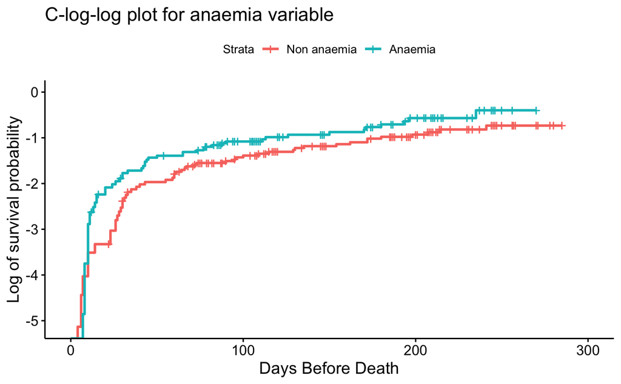

```r
cloglog <- function(x)
{ log(-log(x))}

ggsurvplot(df_anaemia_fit, fun=cloglog, legend.labs=c("Non anaemia","Anaemia"))+labs(x="Days Before Death",y="Log of survival probability",title="C-log-log plot for anaemia variable")
```

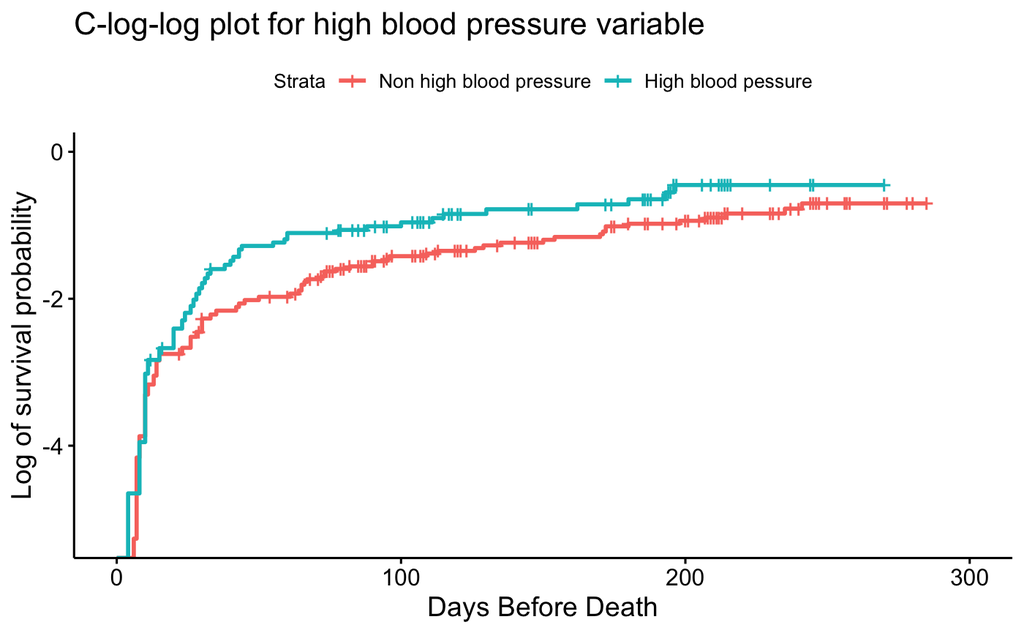

```r
ggsurvplot(df_blood_fit, fun=cloglog, legend.labs=c("Non high blood pressure","High blood pessure"))+labs(x="Days Before Death",y="Log of survival probability",title="C-log-log plot for high blood pressure variable")
```

```r
#Perform row-deletion to test stability of the model
dat <- df
cox6_fit_final = coxph(Surv(time,DEATH_EVENT)  ~ age +ejection_fraction + serum_creatinine +anaemia+ high_blood_pressure+ creatinine_phosphokinase , data=dat)
summary (cox6_fit_final)
```

```
Call:
coxph(formula = Surv(time, DEATH_EVENT) ~ age + ejection_fraction +
    serum_creatinine + anaemia + high_blood_pressure + creatinine_phosphokinase,
    data = dat)

  n= 299, number of events= 96

                               coef  exp(coef)   se(coef)      z Pr(>|z|)
age                       4.361e-02  1.045e+00  8.853e-03  4.926 8.41e-07 ***
ejection_fraction        -5.179e-02  9.495e-01  1.005e-02 -5.152 2.57e-07 ***
serum_creatinine          3.483e-01  1.417e+00  6.550e-02  5.318 1.05e-07 ***
anaemia                   3.933e-01  1.482e+00  2.129e-01  1.847   0.0648 .
high_blood_pressure       4.668e-01  1.595e+00  2.129e-01  2.192   0.0284 *
creatinine_phosphokinase  1.965e-04  1.000e+00  9.856e-05  1.993   0.0462 *
---
Signif. codes:  0 ‘***’ 0.001 ‘**’ 0.01 ‘*’ 0.05 ‘.’ 0.1 ‘ ’ 1

                         exp(coef) exp(-coef) lower .95 upper .95
age                         1.0446     0.9573    1.0266    1.0629
ejection_fraction           0.9495     1.0531    0.9310    0.9684
serum_creatinine            1.4167     0.7059    1.2460    1.6108
anaemia                     1.4818     0.6749    0.9762    2.2493
high_blood_pressure         1.5948     0.6270    1.0506    2.4209
creatinine_phosphokinase    1.0002     0.9998    1.0000    1.0004

Concordance= 0.738  (se = 0.028 )
Likelihood ratio test= 77.02  on 6 df,   p=1e-14
Wald test            = 85.82  on 6 df,   p=2e-16
Score (logrank) test = 83.51  on 6 df,   p=7e-16
```

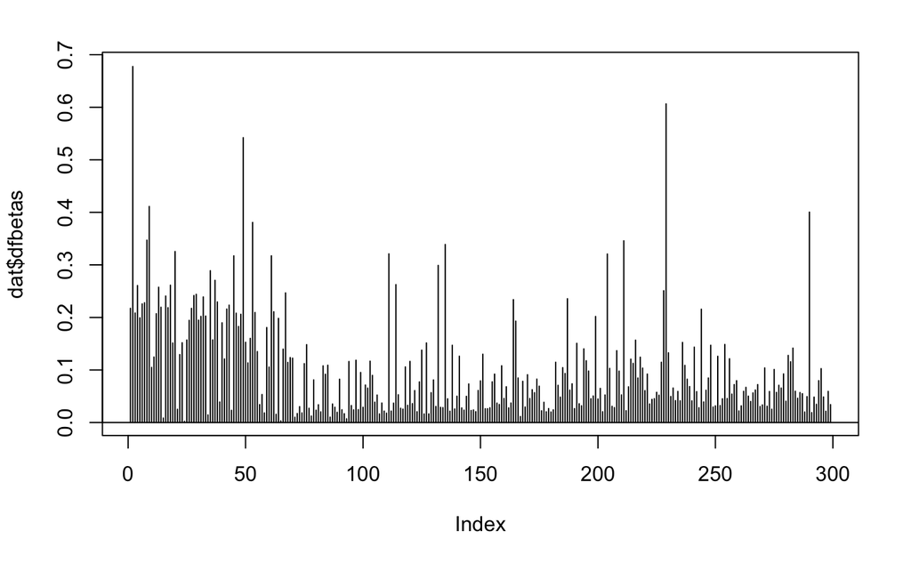

```r
 dfbetas = residuals(cox6_fit_final , type = 'dfbetas')
dat$dfbetas = sqrt(rowSums(dfbetas^2))

plot(dat$dfbetas , type = 'h')
 abline(h = 0)
```

```r
set.seed(123214)
i.training <- sample.int(nrow(df), size = ceiling(nrow(df)/75), replace = FALSE)
i.testing <- setdiff(seq_len(nrow(df)), i.training)
df_pred <- df[i.training, ]

df_pred
```

|  | age | anaemia | creatinine_phosphokinase | diabetes | ejection_fraction | high_blood_pressure | platelets | serum_creatinine | serum_sodium | sex | smoking | time | DEATH_EVENT |
| --- | --- | --- | --- | --- | --- | --- | --- | --- | --- | --- | --- | --- | --- |
| 6 | 90 | 1 | 47 | 0 | 40 | 1 | 204000 | 2.10 | 132 | 1 | 1 | 8 | 1 |
| 5 | 65 | 1 | 160 | 1 | 20 | 0 | 327000 | 2.70 | 116 | 0 | 0 | 8 | 1 |
| 133 | 46 | 0 | 719 | 0 | 40 | 1 | 263358 | 1.18 | 137 | 0 | 0 | 107 | 0 |
| 17 | 87 | 1 | 149 | 0 | 38 | 0 | 262000 | 0.90 | 140 | 1 | 0 | 14 | 1 |

```r
data_new <- df_pred
pred.cph <- survfit(cox6_fit_final, newdata = data_new, type = "aalen")
pred.cph
```

```
Call: survfit(formula = cox6_fit_final, newdata = data_new, type = "aalen")

      n events median 0.95LCL 0.95UCL
6   299     96     43      28     135
5   299     96     64      38     162
133 299     96     NA      NA      NA
17  299     96    150      73      NA
```

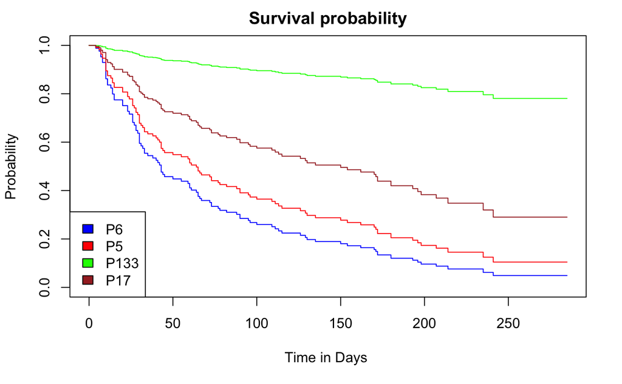

```r
plot(pred.cph, main = "Survival probability", xlab = "Time in Days ", ylab = "Probability", col= c("blue","red", "green", "brown"))
legend("bottomleft",legend = c("P6","P5", "P133", "P17"),fill=c("blue","red", "green", "brown"))
```